# Final Review, Part 1

Adam Raikes

April 7, 2017

# Purpose

The purpose of this slide show is to review some of the basic concepts we’ve covered in this course in preparation for the CAOS post-test.

Note that the post-test does not require any knowledge of R.

# The Normal Distribution

# The Normal Distribution

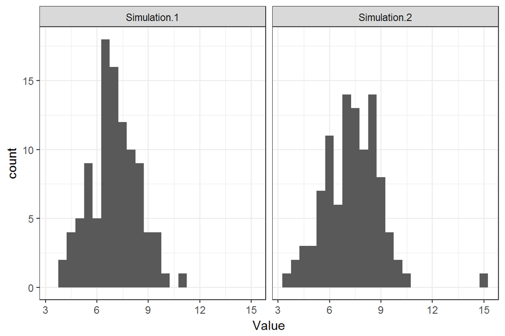

# The Normal Distribution

Which boxplot reflects Simulation 1?

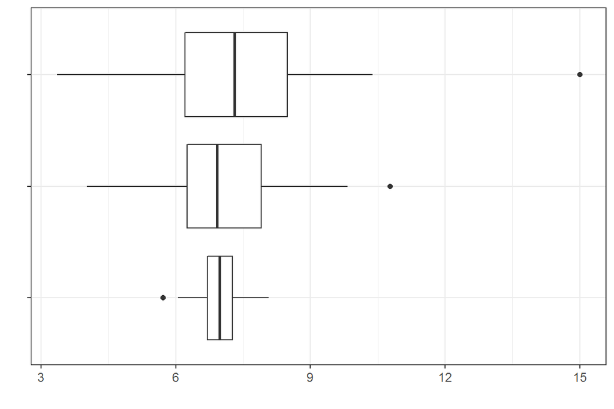

# Other Distributions

A uniform distribution occurs when something is equally likely, like the rolls of a single six-sided die.

Use the following link to simulate a single six-sided die thrown multiple times (10 to 10000) and examine the distribution.

What other sorts of things might reflect a uniform distribution?

https://pep4400.shinyapps.io/DieSim/

# Skewed Distribution

What would the distribution look like the die wasn’t fair and was weighted toward high numbers ($\geq 4$)

# What’s Wrong With This Plot

We want to know the general distribution of yellow M & Ms in order to understand the shape, center, and spread of the count of M&Ms per bag.

# What’s Wrong With This Plot

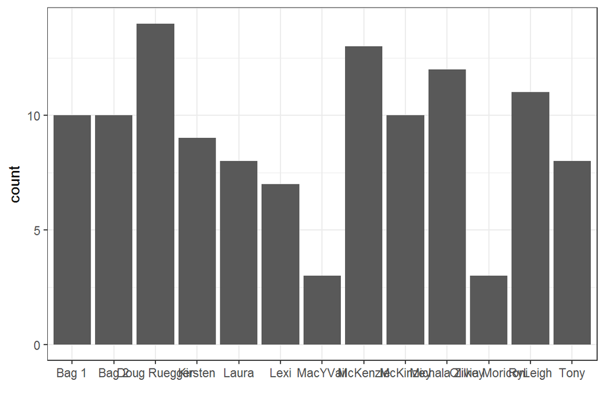

# What’s Wrong With This Plot

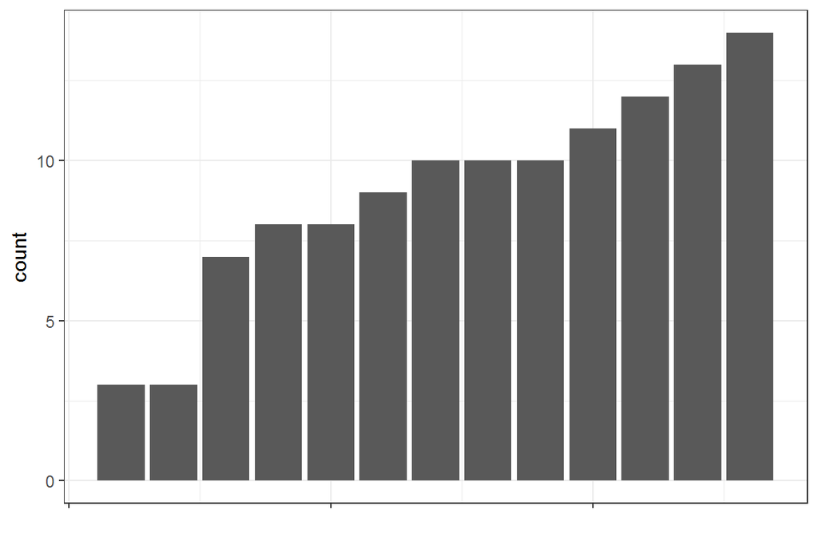

# What Should It Be?

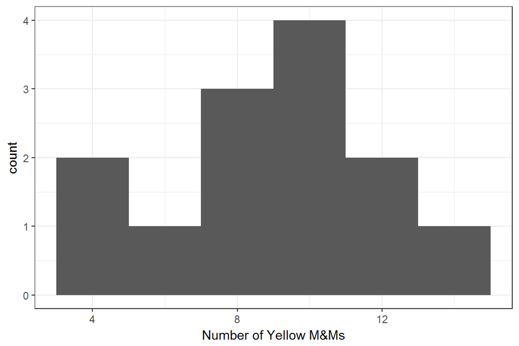

# More About Data Spread

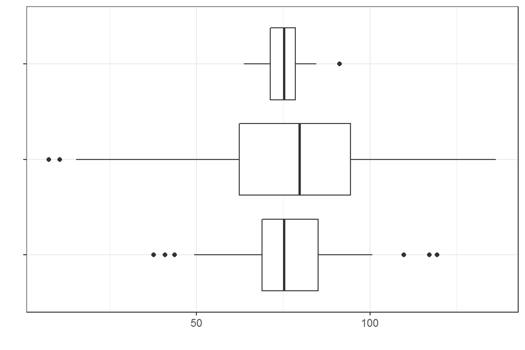

# More About Data Spread

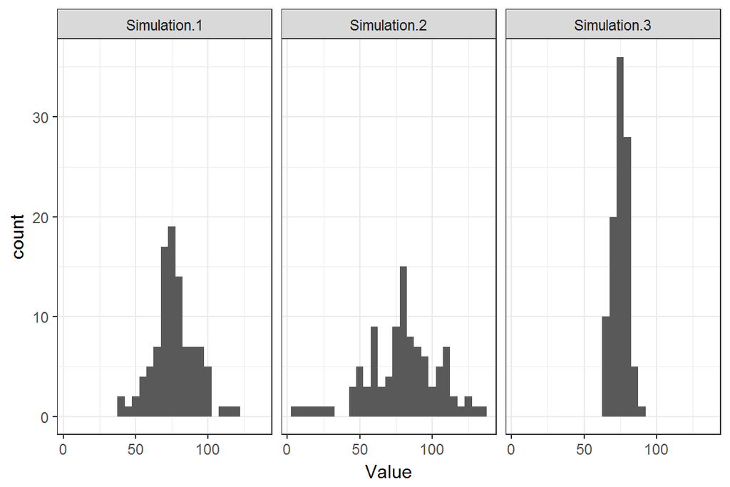